# 01 - Coalescent founders, 3 breeds x 4 countries, phenotypic burn-in

Prepared by Emmanuel Ismaila for QGG, Aarhus University

# 1 What this file does

Mode: **FULL** | between-country r<sub>g</sub>: **1**

# 2 Inputs

```r
h2    <- fread(if (params$param_set == "SFh008") "params/h2_SFh008.csv" else "params/h2.csv")
# param_set (sensitivity analyses, file 00): NUEx0 / NUEx05 change the correlations, SFh008 the Saved Feed h2
RG    <- readRDS(if (params$param_set %in% c("NUEx0", "NUEx05")) sprintf("params/RG_matrix_%s.rds", params$param_set) else "params/RG_matrix.rds")
split <- fread("params/breed_country_split.csv")
traits    <- h2$code
nT        <- length(traits)
breeds    <- c("HOL", "RDC", "JER")
countries <- unique(split$country)            # DNK, SWE, FIN, DEU (file 00)
herds_tab <- fread("params/herds.csv")       # 40 single-breed herds per breed x country (file 00)
nC        <- length(countries)
kable(h2[, .(code, HOL, RDC, JER, status)])
```

| code | HOL | RDC | JER | status |
| --- | --- | --- | --- | --- |
| MY | 0.430 | 0.390 | 0.440 | VERIFIED |
| PY | 0.350 | 0.330 | 0.380 | VERIFIED |
| SF | 0.230 | 0.230 | 0.230 | PROXY-NORDIC (ReFI, a feed-saved metric; Nordic Red only; +-1 SE as range) |
| SCS | 0.095 | 0.115 | 0.095 | VERIFIED (midpoint) |
| LNVAR | 0.220 | 0.220 | 0.220 | VERIFIED-EU (midpoint) |
| ICF | 0.050 | 0.040 | 0.040 | VERIFIED |
| LONG | 0.056 | 0.056 | 0.056 | VERIFIED (midpoint, via review) |
| MUN | 0.220 | 0.240 | 0.180 | VERIFIED |
| NUE | 0.130 | 0.130 | 0.130 | VERIFIED-EU (midpoint) |
| CH4 | 0.175 | 0.175 | 0.175 | VERIFIED-DK, Holstein only (midpoint of parity groups) |
| FY | 0.360 | 0.340 | 0.350 | VERIFIED |

# 3 Design choices (not taken from literature, flagged)

Every number below is a modelling decision. None is presented as an empirical estimate.

```r
FULL <- params$run_mode == "FULL"
design <- list(
  n_founder_per_breed = if (FULL) 600 else 150,   # founder individuals per breed from MaCS
  scale               = if (FULL) 1 else 0.05,    # TEST mode = 5% of 28,400 cows
  n_chr               = 29,                       # bovine autosomes (was 10)
  seg_sites_per_chr   = 2500,                     # candidate segregating sites kept per chr (>= SNP + QTL)
  snp_per_chr         = 345,                      # 29 x 345 = 10,005 SNP (50k planned for the cluster; was 10 x 500)
  qtl_per_chr         = 100,                      # 2,900 QTL per trait, non-overlapping with SNP
  split_gen_HOL_RDC   = 30,                       # generations ago, HOL and RDC lineages join
  split_gen_JER       = 50,                       # generations ago, JER joins the others
  herds               = nrow(herds_tab),          # 39 CFIT farms scaled to 40 (file 00)
  herd_var_prop       = 0.15,                     # herd-generation variance as share of base var(P)
  n_burnin_gen        = 10,                       # generations of phenotypic selection
  sires_per_breed     = round(setNames(split[, sum(n), by = breed]$V1, split[, sum(n), by = breed]$breed) / 200),  # 1 sire per 200 cows
  dam_prop            = 0.80                      # proportion of cows kept as dams
)
kable(data.table(parameter = names(design),
                 value = sapply(design, function(x) paste(x, collapse = " / ")),
                 basis = c("compute budget", "compute budget", "compute budget", "brief",
                           "choice", "assumption: breed formation ~ 19th century (not a published estimate)",
                           "assumption (as above)", "CFIT: 39 farms (12 RDC, 11 JER, 16 HOL) scaled to 40, largest remainder (file 00)",
                           "assumption; herd fitted as fixed block downstream",
                           "choice", "assumption: 1 sire per 200 cows (no public sire numbers found)", "assumption")))
```

[output not shown]

```r
n_breed <- split[, .(n = sum(n)), by = breed]
n_breed[, n_sim := round(n * design$scale)]
n_breed
```

```
##    breed     n n_sim
## 1:   RDC  8100  8100
## 2:   JER  8300  8300
## 3:   HOL 12000 12000
```

# 4 Founder genomes: coalescent with a three-breed split

The command below is AlphaSimR’s own CATTLE command (copied from `runMacs()` source, AlphaSimR 2.1.0), with the two-population split replaced by three islands (`-I 3`) that join backwards in time (`-ej`). MaCS time is in units of 4N<sub>e</sub> generations.

```r
nB      <- design$n_founder_per_breed
Ne      <- 90                                     # MacLeod et al. 2013, as in AlphaSimR
chrBp   <- 2.8e9 / 30                            # AlphaSimR CATTLE: 2.8 Gb over 30 chr; 29 autosomes x 93 Mb = 2.7 Gb
recRate <- 9.26e-9; mutRate <- 9.4e-9
genLen  <- recRate * chrBp                         # Morgans per chromosome
histNe  <- c(120, 250, 350, 1000, 1500, 2000, 2500, 3500, 7000, 10000, 17000, 62000)
histGen <- c(  3,   6,  12,   18,   24,  154,  454,  654, 1754,  2354,  3354, 33154)
hist    <- paste(sprintf("-eN %s %s", histGen / (4 * Ne), histNe / Ne), collapse = " ")
nHap    <- 2 * nB                                  # haplotypes per breed
# runMacs() prepends the sample size (2 x nInd haplotypes) and appends "-s <seed>" itself
cmd <- paste(
  round(chrBp), "-t", mutRate * 4 * Ne, "-r", recRate * 4 * Ne,
  "-I 3", nHap, nHap, nHap, hist,
  "-ej", design$split_gen_HOL_RDC / (4 * Ne) + 1e-6, "2 1",
  "-ej", design$split_gen_JER     / (4 * Ne) + 1e-6, "3 1")
cat(cmd, "\n")
```

```
## 93333333 -t 3.384e-06 -r 3.3336e-06 -I 3 1200 1200 1200 -eN 0.00833333333333333 1.33333333333333 -eN 0.0166666666666667 2.77777777777778 -eN 0.0333333333333333 3.88888888888889 -eN 0.05 11.1111111111111 -eN 0.0666666666666667 16.6666666666667 -eN 0.427777777777778 22.2222222222222 -eN 1.261111111…
```

```r
# Founder cache. The founders depend only on the seed (seed + rep_id) and the MaCS
# settings, and nothing random happens before this chunk. So every burn-in with the same rep_id
# (main, rg 0.9, NUEx0, NUEx05, SFh008) already drew identical founders; the cache only avoids
# re-running MaCS. The RNG state after MaCS is stored with the founders and restored, so a cached
# run continues with exactly the random numbers an uncached run would use.
dir.create("founders", showWarnings = FALSE)
fkey   <- sprintf("founders/founders_seed%d_nInd%d_chr%d_seg%d_%s.rds", params$seed + params$rep_id,
                  3 * nB, design$n_chr, design$seg_sites_per_chr,
                  substr(digest::digest(cmd), 1, 10))
if (file.exists(fkey)) {
  fc <- readRDS(fkey); founders <- fc$founders
  assign(".Random.seed", fc$rng, envir = globalenv())
  cat("Founders read from cache:", fkey, "\n")
} else {
  # nThreads = 2: MaCS runs chromosomes in parallel; the per-chromosome MaCS seeds are drawn in R
  # before the parallel loop, so the thread count does not change the founders.
  founders <- runMacs(nInd = 3 * nB, nChr = design$n_chr,
                      segSites = design$seg_sites_per_chr,
                      manualCommand = cmd, manualGenLen = genLen,
                      nThreads = max(1, parallel::detectCores()))
  saveRDS(list(founders = founders, rng = get(".Random.seed", envir = globalenv()), cmd = cmd), fkey)
  cat("Founders simulated and cached:", fkey, "\n")
}
```

```
## Founders read from cache: founders/founders_seed20261031_nInd1800_chr29_seg2500_92406c0464.rds
```

```r
founders
```

```
## An object of class "MapPop"
## Ploidy: 2
## Individuals: 1800
## Chromosomes: 29
## Loci: 72500
```

```r
if (isTRUE(params$founders_only)) knitr::knit_exit()
```

# 5 Global simulation parameters

```r
SP <- SimParam$new(founders)
SP$restrSegSites(minQtlPerChr = design$qtl_per_chr,
                 minSnpPerChr = design$snp_per_chr, overlap = FALSE)

# Country GxE: each trait x country is its own correlated trait.
# Genetic covariance = kronecker(country correlation, trait correlation).
if (params$gxe_rg < 1) {
  Rc <- matrix(params$gxe_rg, nC, nC); diag(Rc) <- 1
  CORR <- kronecker(Rc, RG)
  trait_names <- as.vector(t(outer(countries, traits, paste, sep = "_")))
} else {
  CORR <- RG                                   # NAV assumption: same genetics in all countries
  trait_names <- traits
}
stopifnot(min(eigen(CORR, only.values = TRUE)$values) > 0)
SP$addTraitA(nQtlPerChr = design$qtl_per_chr, mean = rep(0, ncol(CORR)),
             var = rep(1, ncol(CORR)), corA = CORR, name = trait_names)
SP$addSnpChip(nSnpPerChr = design$snp_per_chr)
SP$setSexes("yes_sys")
SP$setTrackPed(TRUE)
cat("Traits:", SP$nTraits, "| SNP:", sum(SP$snpChips[[1]]@lociPerChr), "\n")
```

```
## Traits: 11 | SNP: 10005
```

Genetic values are on a **standardised scale** (founder additive variance = 1 per trait). Results are therefore reported in genetic standard deviations, not in kg or %.

## 5.1 Breed populations and check that the split worked

Haplotypes come out of MaCS in island order, so individuals `1:nB` are island 1 (HOL), the next `nB` are RDC, the last `nB` are JER. The check below tests that assumption with Nei’s G<sub>ST</sub> on the SNP panel: if island order were wrong, G<sub>ST</sub> would be ~0.

```r
base <- lapply(seq_along(breeds), function(i) newPop(founders[((i - 1) * nB + 1):(i * nB)]))
names(base) <- breeds

gst <- function(popA, popB) {
  pa <- colMeans(pullSnpGeno(popA)) / 2; pb <- colMeans(pullSnpGeno(popB)) / 2
  pbar <- (pa + pb) / 2
  HT <- 2 * pbar * (1 - pbar); HS <- (2 * pa * (1 - pa) + 2 * pb * (1 - pb)) / 2
  (mean(HT) - mean(HS)) / mean(HT)               # ratio of averages across loci
}
gst_tab <- data.table(pair = c("HOL-RDC", "HOL-JER", "RDC-JER"),
                      GST  = c(gst(base$HOL, base$RDC), gst(base$HOL, base$JER),
                               gst(base$RDC, base$JER)))
kable(gst_tab, digits = 4)
```

| pair | GST |
| --- | --- |
| HOL-RDC | 0.0272 |
| HOL-JER | 0.0321 |
| RDC-JER | 0.0319 |

```r
# Expectation from the design: HOL-RDC split more recently -> smallest GST
stopifnot(gst_tab[pair == "HOL-RDC", GST] < gst_tab[pair == "HOL-JER", GST])
```

**Limitation:** no published F<sub>ST</sub>/G<sub>ST</sub> between Nordic Holstein, Red Dairy Cattle and Jersey was sourced, so the split times are **not calibrated** to real breed differentiation. The values above only confirm that the three founder groups are distinct and in the intended order. With a published between-breed F<sub>ST</sub>, the split times can be tuned to match it.

# 6 Population structure, blocking and phenotypes

Each cow belongs to a **breed** (factor), a **country** (factor) and a **herd** (block nested in breed x country). Herds are **single-breed**, as on the CFIT farms (40 herds, file 00), and cows go to countries in the CFIT proportions of their breed. Herd effects are redrawn every generation (herd-generation). Phenotype = genetic value for the cow’s country + herd effect + residual. Residual variance is set **per breed** so that h<sup>2</sup> in the base generation equals the breed-specific value from file 00.

```r
# Herds come from file 00 (single-breed herds per breed x country); same herds in TEST and FULL mode
all_herds    <- herds_tab$herd
herd_country <- herds_tab$country
herd_breed   <- herds_tab$breed

# Cows of breed b go to countries in the CFIT proportions of that breed (largest remainder, ties by
# country order) and are spread evenly over that breed's herds in the country (single-breed herds).
assign_blocks <- function(n, gen, b) {
  sp <- split[breed == b][match(countries, country)]
  x <- n * sp$n / sum(sp$n); k <- floor(x); left <- n - sum(k)
  if (left > 0) { o <- order(-(x - k), seq_along(x)); k[o[seq_len(left)]] <- k[o[seq_len(left)]] + 1 }
  cty <- rep(countries, k)
  hrd <- character(n)
  for (c in countries) {
    i <- which(cty == c); h <- all_herds[herd_breed == b & herd_country == c]
    if (length(i)) hrd[i] <- rep(h, length.out = length(i))[sample.int(length(i))]
  }
  o <- sample.int(n)
  data.table(country = cty[o], herd = hrd[o], generation = gen)
}

# One standard-normal herd-generation effect per herd and trait (herds are single-breed);
# scaled by each breed's herd SD inside make_pheno().
draw_herd_z <- function() matrix(rnorm(length(all_herds) * nT), ncol = nT,
                                 dimnames = list(all_herds, traits))

# Base residual variance per breed and trait, from base-generation additive variance
varE <- sapply(breeds, function(b) {
  vA <- diag(varA(base[[b]]))[seq_len(nT)]       # country 1 columns (identical var by design)
  hb <- h2[[b]]
  vA * (1 - hb) / hb
})
rownames(varE) <- traits
herd_sd <- sqrt(design$herd_var_prop * (1 + varE))   # approx. share of base var(P)
round(varE, 3)
```

```
##          HOL    RDC    JER
## MY     1.305  1.396  1.325
## PY     1.528  1.623  1.529
## SF     3.278  2.548  3.201
## SCS    9.281  6.980  9.068
## LNVAR  3.027  3.261  3.565
## ICF   17.639 18.650 21.187
## LONG  14.101 12.494 14.735
## MUN    3.379  2.880  5.007
## NUE    5.455  5.270  6.328
## CH4    4.311  4.178  4.882
## FY     1.635  1.809  1.848
```

```r
make_pheno <- function(pop, breed, blocks, herd_z) {
  G <- gv(pop)
  if (params$gxe_rg < 1) {                     # pick each cow's own-country columns
    G <- t(sapply(seq_len(nInd(pop)), function(k) {
      cidx <- match(blocks$country[k], countries)
      G[k, ((cidx - 1) * nT + 1):(cidx * nT)]
    }))
  }
  H <- sweep(herd_z, 2, herd_sd[, breed], `*`)
  E <- matrix(rnorm(nInd(pop) * nT, 0, rep(sqrt(varE[, breed]), each = nInd(pop))), ncol = nT)
  P <- G + H[blocks$herd, , drop = FALSE] + E
  colnames(P) <- traits; colnames(G) <- traits
  list(P = P, G = G)
}
```

# 7 Expand founders to the target cow numbers

```r
grow <- function(pop, n_target) {
  while (nInd(pop) < 2 * n_target) {
    pop <- randCross(pop, nCrosses = min(2 * n_target, 2 * nInd(pop)), nProgeny = 1)
  }
  pop
}
cur <- lapply(breeds, function(b) grow(base[[b]], n_breed[breed == b, n_sim]))
names(cur) <- breeds
sapply(cur, nInd)
```

```
##   HOL   RDC   JER
## 24000 16200 16600
```

# 8 Phenotypic burn-in

**Rationale:** before genomic selection the Nordic programmes selected mainly on production. To mimic that history without inventing breeding-value accuracies, the burn-in uses only recorded information:

- **Cows** are phenotyped (herd-corrected) and the top 80% become dams.
- **Bulls** have no own record, so they are selected on their **dam’s** herd-corrected yield index (dam selection).
- Selection index during burn-in = standardised MY + PY (historical yield selection).

```r
records <- list(); pedigree <- list(); trend <- list(); snpfreq <- list()
nSnp <- ncol(pullSnpGeno(cur[[1]][1]))
# allele frequencies chunk-wise (28,400 cows x 50k SNP as integers would need ~5.7 GB)
snp_p <- function(pop, size = 2000) {
  ix <- split(seq_len(nInd(pop)), ceiling(seq_len(nInd(pop)) / size))
  Reduce(`+`, lapply(ix, function(i) colSums(pullSnpGeno(pop[i])))) / (2 * nInd(pop))
}
prev_idx <- setNames(vector("list", 3), breeds)
kept_cows <- list()

for (gen in 0:design$n_burnin_gen) {
  next_gen <- list()
  herd_z   <- draw_herd_z()                      # herd-generation effects (one per single-breed herd)
  for (b in breeds) {
    pop   <- cur[[b]]
    cows  <- pop[pop@sex == "F"]; bulls <- pop[pop@sex == "M"]
    n_cow <- n_breed[breed == b, n_sim]
    cows  <- cows[seq_len(min(n_cow, nInd(cows)))]
    blk   <- assign_blocks(nInd(cows), gen, b)
    # SNP allele frequencies of this generation's cows: base frequencies for metafounders (file 02)
    snpfreq[[paste(gen, b)]] <- data.table(generation = gen, breed = b, snp = seq_len(nSnp),
                                           p = snp_p(cows))
    ph    <- make_pheno(cows, b, blk, herd_z)

    rec <- data.table(id = cows@id, sire = cows@father, dam = cows@mother, breed = b, blk,
                      ph$P)
    # true breeding values (simulation truth, used only to score accuracy, never in models)
    tbv <- ph$G; colnames(tbv) <- paste0("TBV_", traits)
    records[[paste(gen, b)]] <- cbind(rec, tbv)
    # keep the genomes of the last three generations' cows for genomic prediction (file 02)
    if (gen >= design$n_burnin_gen - 2) kept_cows[[paste(gen, b)]] <- cows
    pedigree[[paste(gen, b)]] <- data.table(id = pop@id, sire = pop@father,
                                            dam = pop@mother, sex = pop@sex,
                                            breed = b, generation = gen)
    trend[[paste(gen, b)]] <- data.table(
      generation = gen, breed = b, trait = traits,
      mean_G = colMeans(ph$G), var_G = apply(ph$G, 2, var),
      mean_P = colMeans(ph$P), var_P = apply(ph$P, 2, var))

    if (gen == design$n_burnin_gen) next

    # herd-corrected yield index (':=' keeps the original row order)
    Pc   <- copy(rec)[, (traits) := lapply(.SD, function(x) x - mean(x)),
                      by = herd, .SDcols = traits]
    idx  <- as.numeric(scale(Pc$MY) + scale(Pc$PY))
    names(idx) <- rec$id
    dams <- cows[order(-idx)[seq_len(round(design$dam_prop * nInd(cows)))]]
    # Bulls are sons of the PREVIOUS generation's dams, so rank them on that index.
    # Generation 0 has no recorded dams -> random choice (sample).
    bull_idx <- if (is.null(prev_idx[[b]])) runif(nInd(bulls)) else prev_idx[[b]][bulls@mother]
    bull_idx[is.na(bull_idx)] <- 0
    sires <- bulls[order(-bull_idx)[seq_len(design$sires_per_breed[[b]])]]
    prev_idx[[b]] <- idx
    next_gen[[b]] <- randCross2(dams, sires, nCrosses = 2 * n_cow, nProgeny = 1)
  }
  if (gen < design$n_burnin_gen) cur <- next_gen
}
records  <- rbindlist(records)
pedigree <- rbindlist(pedigree)
trend    <- rbindlist(trend)
cat("Records:", nrow(records), "| Pedigree rows:", nrow(pedigree), "\n")
```

```
## Records: 312400 | Pedigree rows: 624800
```

# 9 Checks

## 9.1 Realised heritability in the base generation

If the residual variances were set correctly, var(G)/var(P) in generation 0 should be close to the target h<sup>2</sup> (herd variance makes it slightly lower, since the herd block is part of var(P)).

```r
chk <- trend[generation == 0, .(breed, trait, realised_h2 = var_G / var_P)]
chk <- merge(chk, melt(h2[, .(trait = code, HOL, RDC, JER)], id.vars = "trait",
                       variable.name = "breed", value.name = "target_h2"),
             by = c("breed", "trait"))
chk[, ratio := realised_h2 / target_h2]
kable(dcast(chk, trait ~ breed, value.var = "ratio"), digits = 2,
      caption = "Realised / target h2 in generation 0 (expected slightly < 1 because of herd variance)")
```

Realised / target h2 in generation 0 (expected slightly < 1 because of herd variance)

| trait | HOL | JER | RDC |
| --- | --- | --- | --- |
| CH4 | 0.93 | 0.84 | 0.97 |
| FY | 0.97 | 0.94 | 0.96 |
| ICF | 0.82 | 0.92 | 0.96 |
| LNVAR | 0.96 | 0.81 | 0.95 |
| LONG | 0.89 | 0.86 | 0.89 |
| MUN | 0.89 | 0.84 | 0.85 |
| MY | 0.91 | 0.93 | 0.98 |
| NUE | 0.89 | 0.82 | 0.95 |
| PY | 0.95 | 0.85 | 1.00 |
| SCS | 0.82 | 0.89 | 0.92 |
| SF | 0.78 | 0.85 | 0.92 |

## 9.2 Mean and variance of genetic and phenotypic values over the burn-in

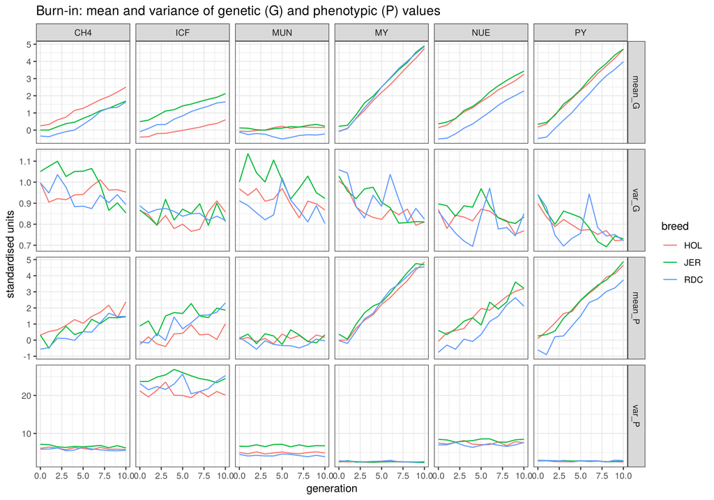

```r
tl <- melt(trend, id.vars = c("generation", "breed", "trait"))
ggplot(tl[trait %in% c("MY", "PY", "MUN", "NUE", "CH4", "ICF")],
       aes(generation, value, colour = breed)) +
  geom_line() + facet_grid(variable ~ trait, scales = "free_y") +
  labs(title = "Burn-in: mean and variance of genetic (G) and phenotypic (P) values",
       y = "standardised units") + theme_bw()
```

**What to look for:** MY and PY means should rise (they are selected). Other traits follow their r<sub>g</sub> with the yield index (file 00 matrix): NUE r<sub>g</sub> with MY 0.53 and PY 0.77; Saved Feed 0.27 / 0.27; CH4 0.33 / 0.46; ICF 0.29 / 0.29. Traits with r<sub>g</sub> near 0 to both should only drift. var(G) should decline slowly (Bulmer effect + drift).

# 10 Save

```r
out <- sprintf("sim_%s_rg%.2f%s%s", params$run_mode, params$gxe_rg, if (params$param_set != "main") paste0("_", params$param_set) else "",
               if (params$rep_id > 0) paste0("_rep", params$rep_id) else "")
dir.create(out, showWarnings = FALSE)
saveRDS(list(pop = cur, kept_cows = kept_cows, SP = SP, design = design, varE = varE,
             herd_sd = herd_sd, all_herds = all_herds, traits = traits,
             gxe_rg = params$gxe_rg),
        file.path(out, "burnin_state.rds"))
fwrite(records,  file.path(out, "phenotypes.csv"))
fwrite(pedigree, file.path(out, "pedigree.csv"))
fwrite(trend,    file.path(out, "trend_burnin.csv"))
fwrite(gst_tab,  file.path(out, "gst_founders.csv"))
fwrite(rbindlist(snpfreq), file.path(out, "snp_freq_by_generation.csv"))
fwrite(h2, file.path(out, "h2_used.csv")); saveRDS(RG, file.path(out, "RG_used.rds"))   # parameters of this burn-in (read by file 04)
list.files(out)
```

```
## [1] "RG_used.rds"                "burnin_state.rds"
## [3] "gst_founders.csv"           "h2_used.csv"
## [5] "pedigree.csv"               "phenotypes.csv"
## [7] "snp_freq_by_generation.csv" "trend_burnin.csv"
```

```r
cat("Run time:", format(Sys.time() - t0), "\n")
```

```
## Run time: 5.554312 mins
```